# H2O autoML shinyapp funcs

### What is H2O?

H2O is the scalable open source ML platform that offers parallelized implementations of many supervised and unsupervised machine learning algorithms.

H2O installation requires Java Development Kit (JDK 11) be installed on your machines. [Go here](https://www.oracle.com/java/technologies/javase-downloads.html) and download Java SE 11 (not the latest Java SE 16!)

Why care abut H2O? Coz it enables **auto-ML** functionality.

### About Auto-ML with h2o

Automated ML automates the supervised machine learning model training process. The current version of AutoML:

- trains and cross-validates the following algorithms (in order)
  - three pre-specified XGBoost GBM (Gradient Boosting Machine) models,
  - a fixed grid of GLMs (Generalized linear models),
  - a default Random Forest (DRF),
  - five pre-specified H2O GBMs,
  - a near-default Deep Neural Net,
  - an Extremely Randomized Forest (XRT),
  - a random grid of XGBoost GBMs,
  - a random grid of H2O GBMs, and
  - a random grid of Deep Neural Nets.

In some cases, there will not be enough time to complete all the algorithms, so some may be missing from the *leaderboard*. AutoML then trains two Stacked Ensemble models, one of all the models, and one of only the best models of each kind.

- Auto-ML ke advantages
  - One can sample from different models
  - tweak this model or that,
  - mix and match across model a bit if needed,
  - have no worries about parameter tuning which is a bear otherwise,
  - pull and save any model estimated,
  - predict with any model fitted,
  - and on and on …

So, why wait? Let’s get started.

```r
suppressPackageStartupMessages({
  library(magrittr)
  library(ggplot2)
  library(h2o)
})
    # intialize the h2o instance
```

If all went well above, we’re in business. Read-in data.

### Planning the UI and Outputs

- UI side will have the following:
  - 2 file input fields - one for calibration_data and one for pred_data.
  - variable selection for Y (default will be first variable)
  - variable selection for X (can drop variables like cust_ID etc)
  - check box for whether Y is a factor variable (i.e. classifn task?)
  - slider for choosing Training sample proportion (0 to 100, default=70)
  - slider for choosing Max Training time (10 to 100 secs, default=30)
- Output tabs will be:
  - Overview and example dataset tab
  - Data Summary (shows first 20 odd rows as HTML table)
  - Results Leaderboard Tab
  - Best Model tab
  - Prediction output tab

Am reusing the telecom churn dataset. Behold.

```r
path0 = "D:/Dropbox/teaching related/MLBM/Co 2021/"

# user inputs DF file
churnData = read.csv(paste0(path0, 'kaggle_Telco_Customer_Churn_cleaned.csv'), header=TRUE)
str(churnData)
```

```
## 'data.frame':    7032 obs. of  22 variables:
##  $ X               : int  0 1 2 3 4 5 6 7 8 9 ...
##  $ customerID      : chr  "7590-VHVEG" "5575-GNVDE" "3668-QPYBK" "7795-CFOCW" ...
##  $ gender          : int  0 1 1 1 0 0 1 0 0 1 ...
##  $ SeniorCitizen   : int  0 0 0 0 0 0 0 0 0 0 ...
##  $ Partner         : int  1 0 0 0 0 0 0 0 1 0 ...
##  $ Dependents      : int  0 0 0 0 0 0 1 0 0 1 ...
##  $ tenure          : int  1 34 2 45 2 8 22 10 28 62 ...
##  $ PhoneService    : int  0 1 1 0 1 1 1 0 1 1 ...
##  $ MultipleLines   : int  1 0 0 1 0 2 2 1 2 0 ...
##  $ InternetService : int  0 0 0 0 1 1 1 0 1 0 ...
##  $ OnlineSecurity  : int  0 2 2 2 0 0 0 2 0 2 ...
##  $ OnlineBackup    : int  2 0 2 0 0 0 2 0 0 2 ...
##  $ DeviceProtection: int  0 2 0 2 0 2 0 0 2 0 ...
##  $ TechSupport     : int  0 0 0 2 0 0 0 0 2 0 ...
##  $ StreamingTV     : int  0 0 0 0 0 2 2 0 2 0 ...
##  $ StreamingMovies : int  0 0 0 0 0 2 0 0 2 0 ...
##  $ Contract        : int  0 1 0 1 0 0 0 0 0 1 ...
##  $ PaperlessBilling: int  1 0 1 0 1 1 1 0 1 0 ...
##  $ PaymentMethod   : int  2 3 3 0 2 2 1 3 2 0 ...
##  $ MonthlyCharges  : num  29.9 57 53.9 42.3 70.7 ...
##  $ TotalCharges    : num  29.9 1889.5 108.2 1840.8 151.7 ...
##  $ Churn           : int  0 0 1 0 1 1 0 0 1 0 ...
```

```r
data = churnData[1:2000,]  # taking a subset for demo

y = data$Churn  # UI selects Y variable for classifiers
X = data[,c(3:21)] # UI drops irrelevant variables from input DF
df0 = data.frame(y,X)  # DF created for use in rest of the app
pred_data = churnData[2001:3000, 3:21] # create fresh data for prediction

# more UI inputs needed
train_propn_ui = 0.7 # from UI, else 70% default. Slider as usual.
max_runtime_secs_ui = 30  # UI. slider from 10 to 100 secs. default=30
i = 3 # Have i=2 as default and a dropdown from 1-10 to select model_id number
classifn = 'TRUE'  # UI for classifn, else regn
```

OK. Now we’re good to go. Will define the workflow and functionize it.

```r
h2o_automl <- function(df0, classifn = TRUE,
                            train_propn_ui=0.7, i=2, pred_data=NULL){

  # Partition input Data
  set.seed(222)
  ind <- sample(2, nrow(df0), replace = TRUE,
                prob = c(train_propn_ui, (1 - train_propn_ui))) # from UI
  train <- df0[ind==1,]
  test <- df0[ind==2,]

  # build H2O frames
  train_h2o = as.h2o(train)
  test_h2o = as.h2o(test)
  pred_h2o = as.h2o(pred_data)

  y <- "y"  # select DV variable name by user
  x <- setdiff(names(train), y)

  'discern classifn vs regn for autoML'
  if (classifn == TRUE){
    train_h2o[,y] <- as.factor(train_h2o[,y]) }

  # Create automl obj by passing the mandatory parms.
  system.time({
    aml <- h2o.automl(x = x, y = y,
                      training_frame = train_h2o,
                      max_runtime_secs = max_runtime_secs_ui) # from UI.
    }) # 46 s


  'Results Leaderboard Tab.'
  ## Viewing the leaderboard of different models.
  lb <- aml@leaderboard; lb
  lb_df = as.data.frame(lb)
  print(lb_df)  # show as HTML table

  # plot leaderboard AUC scores for models estimated.
  if (classifn == TRUE){
    plot1 = ggplot(data=lb_df, aes(seq(1:nrow(lb_df)), auc)) +
            geom_line(colour = 'red') +
            geom_point(colour = "blue") +
            xlab("model number in leaderboard")
  } else {
    plot1 = ggplot(data=lb_df, aes(seq(1:nrow(lb_df)), rmse)) +
            geom_line(colour = 'red') +
            geom_point(colour = "blue") +
            xlab("model number in leaderboard")
  }
  plot(plot1) # show below leaderboard table

  'Best model tab'
  # get details of the best fitting model
  best_model = aml@leader
  cat("==== +++++++ Auto-ML recommended top model is: +++++++ ====\n\n")
  print(best_model)

  ## get the i^th model from the leaderboard
  oth_model = h2o.getModel(as.vector(lb$model_id[i]))
  cat("===== Auto-ML recommended", i,"th model is: =====\n\n")
  print(oth_model)


  'Prediction Tab'
  ## Show Preds from best model (or oth_model) as UI chooses
  pred_out = h2o.predict(best_model, pred_h2o)
  pred_out_df = as.data.frame(pred_out)
  pred_out_df %>% head(15)  # display as HTML. Also as downloadable.

  } # func ends
```

OK. Time to test-drive now.

```r
h2o.init()
```

```
##
## H2O is not running yet, starting it now...
##
## Note:  In case of errors look at the following log files:
##     C:\Users\20052\AppData\Local\Temp\RtmpgRiMnw\file8c7016bd2052/h2o_20052_started_from_r.out
##     C:\Users\20052\AppData\Local\Temp\RtmpgRiMnw\file8c70551823da/h2o_20052_started_from_r.err
##
##
## Starting H2O JVM and connecting:  Connection successful!
##
## R is connected to the H2O cluster:
##     H2O cluster uptime:         2 seconds 540 milliseconds
##     H2O cluster timezone:       Asia/Kolkata
##     H2O data parsing timezone:  UTC
##     H2O cluster version:        3.32.0.1
##     H2O cluster version age:    7 months and 16 days !!!
##     H2O cluster name:           H2O_started_from_R_20052_wyl769
##     H2O cluster total nodes:    1
##     H2O cluster total memory:   29.97 GB
##     H2O cluster total cores:    4
##     H2O cluster allowed cores:  4
##     H2O cluster healthy:        TRUE
##     H2O Connection ip:          localhost
##     H2O Connection port:        54321
##     H2O Connection proxy:       NA
##     H2O Internal Security:      FALSE
##     H2O API Extensions:         Amazon S3, Algos, AutoML, Core V3, TargetEncoder, Core V4
##     R Version:                  R version 4.0.3 (2020-10-10)
```

```r
system.time({
  h2o_automl(df0, classifn = TRUE,
                  train_propn_ui=0.7, i=2, pred_data=pred_data)
})
```

```
##
##
## 21:09:06.233: AutoML: XGBoost is not available; skipping it.
##                                               model_id       auc   logloss
## 1           GBM_grid__1_AutoML_20210524_210906_model_4 0.8757814 0.3772340
## 2                         GBM_5_AutoML_20210524_210906 0.8743668 0.3783450
## 3  StackedEnsemble_BestOfFamily_AutoML_20210524_210906 0.8735320 0.3944057
## 4     StackedEnsemble_AllModels_AutoML_20210524_210906 0.8719303 0.3941497
## 5                         GBM_3_AutoML_20210524_210906 0.8688273 0.3897357
## 6           GBM_grid__1_AutoML_20210524_210906_model_5 0.8655987 0.3918016
## 7           GBM_grid__1_AutoML_20210524_210906_model_2 0.8648559 0.3942766
## 8           GBM_grid__1_AutoML_20210524_210906_model_6 0.8632690 0.4066566
## 9                         GLM_1_AutoML_20210524_210906 0.8620895 0.3920946
## 10                        GBM_4_AutoML_20210524_210906 0.8617649 0.4016072
## 11                        GBM_2_AutoML_20210524_210906 0.8612627 0.3991979
```

[output cut: 32 more lines]

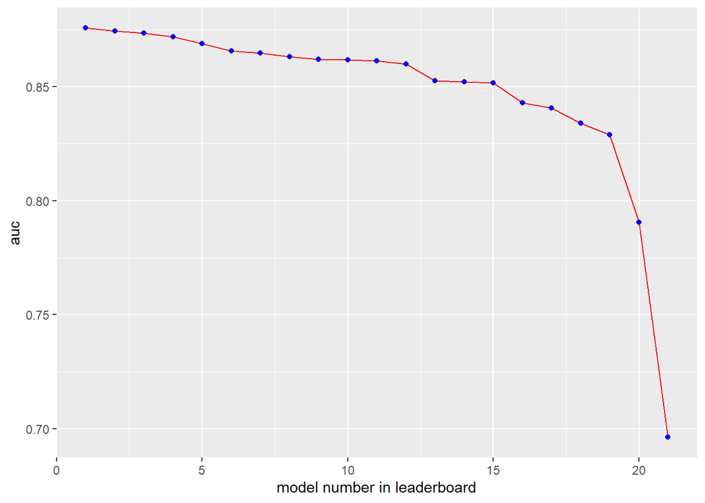

```
## ==== +++++++ Auto-ML recommended top model is: +++++++ ====
##
## Model Details:
## ==============
##
## H2OBinomialModel: gbm
## Model ID:  GBM_grid__1_AutoML_20210524_210906_model_4
## Model Summary:
##   number_of_trees number_of_internal_trees model_size_in_bytes min_depth
## 1              42                       42               17200         7
##   max_depth mean_depth min_leaves max_leaves mean_leaves
## 1         7    7.00000         20         33    27.88095
##
##
## H2OBinomialMetrics: gbm
## ** Reported on training data. **
##
## MSE:  0.08505372
## RMSE:  0.2916397
## LogLoss:  0.2747725
## Mean Per-Class Error:  0.1437266
## AUC:  0.9476835
## AUCPR:  0.8559449
## Gini:  0.8953669
## R^2:  0.5571721
##
## Confusion Matrix (vertical: actual; across: predicted) for F1-optimal threshold:
##           0   1    Error       Rate
## 0       951  83 0.080271   =83/1034
## 1        75 287 0.207182    =75/362
## Totals 1026 370 0.113181  =158/1396
##
## Maximum Metrics: Maximum metrics at their respective thresholds
##                         metric threshold       value idx
## 1                       max f1  0.433869    0.784153 174
## 2                       max f2  0.192608    0.865010 271
## 3                 max f0point5  0.556051    0.791721 134
## 4                 max accuracy  0.433869    0.886819 174
## 5                max precision  0.930243    1.000000   0
## 6                   max recall  0.107585    1.000000 313
```

[output cut: 196 more lines]

```
##                   mean         sd cv_1_valid cv_2_valid cv_3_valid cv_4_valid
## pr_auc      0.69774514 0.09277299 0.74832827 0.66548157  0.7043813 0.56183255
## precision    0.5985738 0.08241956 0.64285713        0.6 0.57723576 0.47580644
## r2           0.3562986 0.08150204 0.38618758 0.30321822 0.38202316 0.24968854
## recall      0.81866163 0.08769112  0.7826087  0.6818182 0.89873415 0.86764705
## rmse         0.3501244  0.0157211   0.337618 0.35473657 0.35416892  0.3718881
## specificity 0.79963285 0.07833143  0.8578199 0.85915494       0.74  0.6919431
##             cv_5_valid
## pr_auc       0.8087021
## precision    0.6969697
## r2           0.4603755
## recall          0.8625
## rmse        0.33221036
## specificity  0.8492462
##
```

```
##    user  system elapsed
##    7.32    2.09   54.78
```

```r
h2o.shutdown()
```

```
## Are you sure you want to shutdown the H2O instance running at http://localhost:54321/ (Y/N)?
```

### Regression autoML

Same can be done for regression too. Am using the calif housing dataset for this. Behold.

```r
# try regression on h2o with calif_housing_df
califh = read.csv(paste0(path0, "califHousing.csv"))
str(califh)
```

```
## 'data.frame':    20640 obs. of  11 variables:
##  $ X                 : int  0 1 2 3 4 5 6 7 8 9 ...
##  $ longitude         : num  -122 -122 -122 -122 -122 ...
##  $ latitude          : num  37.9 37.9 37.9 37.9 37.9 ...
##  $ housing_median_age: num  41 21 52 52 52 52 52 52 42 52 ...
##  $ total_rooms       : num  880 7099 1467 1274 1627 ...
##  $ total_bedrooms    : num  129 1106 190 235 280 ...
##  $ population        : num  322 2401 496 558 565 ...
##  $ households        : num  126 1138 177 219 259 ...
##  $ median_income     : num  8.33 8.3 7.26 5.64 3.85 ...
##  $ median_house_value: num  452600 358500 352100 341300 342200 ...
##  $ ocean_proximity   : chr  "NEAR BAY" "NEAR BAY" "NEAR BAY" "NEAR BAY" ...
```

```r
califh = califh[,2:ncol(califh)] # drop X index var
data = califh[1:5000,]
y = data$median_house_value
X = data[, -y]
df0 = data.frame(y,X)  # Df built for analysis
pred_data = data[6001:8000, -9] # create fresh data for prediction

# applying automl
h2o.init()
```

```
##  Connection successful!
##
## R is connected to the H2O cluster:
##     H2O cluster uptime:         57 seconds 960 milliseconds
##     H2O cluster timezone:       Asia/Kolkata
##     H2O data parsing timezone:  UTC
##     H2O cluster version:        3.32.0.1
##     H2O cluster version age:    7 months and 16 days !!!
##     H2O cluster name:           H2O_started_from_R_20052_wyl769
##     H2O cluster total nodes:    1
##     H2O cluster total memory:   29.96 GB
##     H2O cluster total cores:    4
##     H2O cluster allowed cores:  4
##     H2O cluster healthy:        TRUE
##     H2O Connection ip:          localhost
##     H2O Connection port:        54321
##     H2O Connection proxy:       NA
##     H2O Internal Security:      FALSE
##     H2O API Extensions:         Amazon S3, Algos, AutoML, Core V3, TargetEncoder, Core V4
##     R Version:                  R version 4.0.3 (2020-10-10)
```

```r
system.time({
  h2o_automl(df0, classifn = FALSE, train_propn_ui=0.7, pred_data=pred_data) })
```

```
##
##
## 21:10:01.495: AutoML: XGBoost is not available; skipping it.
##                                               model_id mean_residual_deviance
## 1           GBM_grid__1_AutoML_20210524_211001_model_1           4.700367e+05
## 2     StackedEnsemble_AllModels_AutoML_20210524_211001           9.487572e+05
## 3  StackedEnsemble_BestOfFamily_AutoML_20210524_211001           1.292266e+06
## 4           GBM_grid__1_AutoML_20210524_211001_model_3           2.775993e+07
## 5                         GBM_5_AutoML_20210524_211001           6.545759e+07
## 6                         XRT_1_AutoML_20210524_211001           7.667000e+07
## 7                         GBM_4_AutoML_20210524_211001           8.262416e+07
## 8           GBM_grid__1_AutoML_20210524_211001_model_2           1.231485e+08
## 9                         GBM_3_AutoML_20210524_211001           1.283307e+08
## 10                        GBM_1_AutoML_20210524_211001           1.351771e+08
## 11                        GBM_2_AutoML_20210524_211001           1.554826e+08
```

[output cut: 22 more lines]

```
## ==== +++++++ Auto-ML recommended top model is: +++++++ ====
##
## Model Details:
## ==============
##
## H2ORegressionModel: gbm
## Model ID:  GBM_grid__1_AutoML_20210524_211001_model_1
## Model Summary:
##   number_of_trees number_of_internal_trees model_size_in_bytes min_depth
## 1              96                       96               21815         4
##   max_depth mean_depth min_leaves max_leaves mean_leaves
## 1         4    4.00000          5         16    13.48958
##
##
## H2ORegressionMetrics: gbm
## ** Reported on training data. **
##
## MSE:  210855.5
## RMSE:  459.1901
## MAE:  286.774
## RMSLE:  0.01136816
## Mean Residual Deviance :  210855.5
##
##
##
## H2ORegressionMetrics: gbm
## ** Reported on cross-validation data. **
## ** 5-fold cross-validation on training data (Metrics computed for combined holdout predictions) **
##
## MSE:  470036.7
## RMSE:  685.5922
## MAE:  372.5765
## RMSLE:  0.01820022
## Mean Residual Deviance :  470036.7
##
##
## Cross-Validation Metrics Summary:
##                              mean          sd   cv_1_valid cv_2_valid
## mae                      372.5765   31.558428     328.8238  397.64035
## mean_residual_deviance  470036.72   251568.08     204822.0   579725.0
```

[output cut: 45 more lines]

```
##
##
##
## H2ORegressionMetrics: stackedensemble
## ** Reported on cross-validation data. **
## ** 5-fold cross-validation on training data (Metrics computed for combined holdout predictions) **
##
## MSE:  948757.2
## RMSE:  974.0417
## MAE:  546.611
## RMSLE:  0.01974125
## Mean Residual Deviance :  948757.2
##
##
##
```

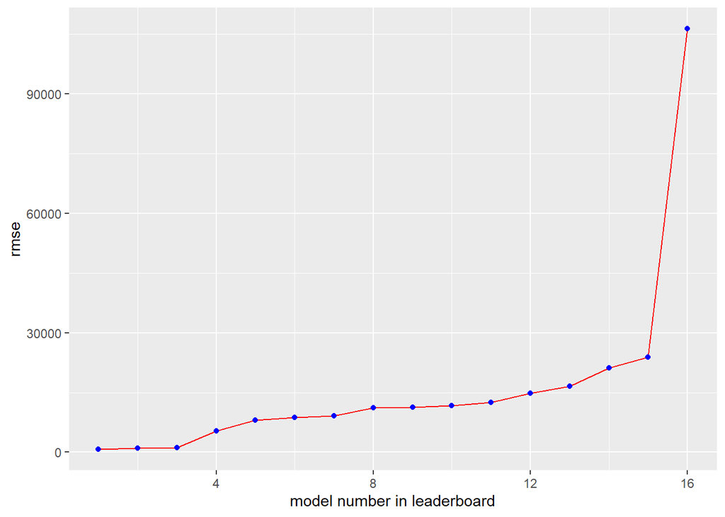

```
##    user  system elapsed
##    7.62    2.16   47.86
```

```r
h2o.shutdown()
```

```
## Are you sure you want to shutdown the H2O instance running at http://localhost:54321/ (Y/N)?
```

Ciao

Sudhir. May 2021